# La Política de la Corrupción

Sesión 8: Cómo se mide la corrupción

Bogdan G. Popescu

bgpopescu@tec.mx

Tecnológico de Monterrey

## Hoy

Si la corrupción se esconde, ¿cómo hace alguien para contarla?

Empiezan ustedes en una sala de redacción, con cinco cifras sobre México.

- Cada cifra es un **rastro** que dejó el acto
- Cuatro familias de rastro, y qué observa cada una
- Por qué lo que la gente **cree** y lo que **vive** se separan
- Qué medida exige cada afirmación, y cómo engaña cada una

## Un país, tres números

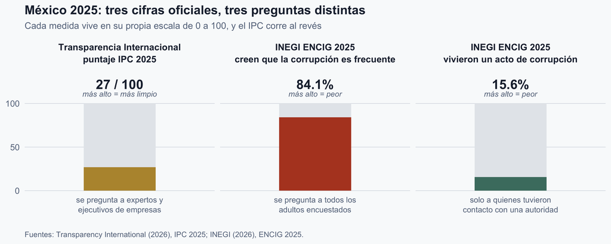

¿Cuál de los números es el verdadero?

## Ejercicio: la sala de redacción

**Ustedes son periodistas.** Su equipo tiene una cifra sobre la corrupción en México y unos minutos para publicar.

1. Un **titular**: máximo diez palabras
2. Un **subtítulo**: máximo veinticinco palabras, que diga qué muestra la evidencia

**La regla.** Su titular debe ser dramático. Su subtítulo tiene que ser exactamente cierto.

## Cinco medidas de la corrupción en México

Todas estas miden la corrupción en México.

Tabla 1: Cinco medidas publicadas de la corrupción en México.

| Qué se mide | Tipo de corrupción | Cambio | Fuente |
| --- | --- | --- | --- |
| Puntaje experto, sector público | Soborno, desvío, captura del Estado | 29 a 27, 2017-2025 | Transparency Int., IPC |
| Adultos que la consideran frecuente | Lo que cada quien imagine | 91.1% a 84.1%, 2017-2025 | INEGI, ENCIG |
| Personas que la vivieron en un trámite | Soborno cotidiano a ciudadanos | 14.6% a 15.6%, 2017-2025 | INEGI, ENCIG |
| Empresas a las que les pidieron soborno | Soborno cotidiano a empresas | 17.6% a 15.8%, 2010-2023 | Banco Mundial (empresas) |
| Costo promedio por víctima | Soborno cotidiano a ciudadanos | 3,368 a 3,865 pesos, 2023-2025 | INEGI, ENCIG |

## Un ejemplo

Hecho con una sexta cifra, que no está en ninguna de las tarjetas.

**Titular.** Dónde vives decide si pagas

**Subtítulo.** En 2025, 21.5% de las personas de Hidalgo que hicieron un trámite vivieron un acto de corrupción, contra 7.0% en Colima.

Fuente: INEGI (2026), ENCIG 2025.

## Un mismo país, cinco titulares

Un momento. Todas describen la corrupción en México. ¿Quién se equivoca?

Tabla 2: Las cinco tarjetas, y un titular que cada una sí sostiene.

| Tarjeta | La cifra | ¿Mejor o peor? | Un titular que sí sostiene |
| --- | --- | --- | --- |
| A | 29 a 27 | peor | Los expertos califican peor a México en corrupción |
| B | 91.1% a 84.1% | MEJOR | Menos mexicanos dicen que la corrupción es frecuente |
| C | 14.6% a 15.6% | peor | Más mexicanos reportan haber vivido corrupción |
| D | 17.6% a 15.8% | MEJOR | A menos empresas les piden sobornos |
| E | 3,368 a 3,865 pesos | peor | Las víctimas de corrupción están pagando más |

Las cinco son correctas, porque cada una contó algo distinto.

# I. Contar algo que se esconde

## Por qué solo hay rastros

¿Por qué nadie puede contar el acto mismo?

- El acto es **ilegal**, así que las dos partes lo esconden
- Nadie denuncia cuando las dos partes salieron ganando
- Las definiciones cambian: ¿regalo, cuota, comisión o soborno?
- A veces se puede observar un soborno; casi nunca se puede
- La medida se conforma con lo que la corrupción deja atrás

**Medida**: un rastro observable que acordamos tratar como sustituto de algo que no podemos ver de forma directa.

Así que cada cifra plantea la misma pregunta: ¿qué dejó este rastro?

Sobre la observación directa de sobornos en campo, véase Sequeira (2012).

# II. Cuatro familias de medidas

## Cuatro rastros de un mismo acto oculto

```
%%{init: {"theme":"base","width":1150,"height":660,
  "themeVariables":{"fontSize":"19px","fontFamily":"Helvetica, Arial, sans-serif",
    "primaryColor":"#f4f6f8","primaryTextColor":"#1e293b",
    "primaryBorderColor":"#64748b","lineColor":"#334155","textColor":"#1e293b"},
  "flowchart":{"useMaxWidth":true,"htmlLabels":true,"nodeSpacing":28,"rankSpacing":110,
    "curve":"basis","padding":26}} }%%
flowchart LR
  H["Un acto de<br/>corrupción oculto"]
  H --> P["1. Percepción<br/>de expertos"]
  H --> E["2. Experiencia de<br/>gente y empresas"]
  H --> A["3. Auditorías y<br/>dinero faltante"]
  H --> M["4. Inferencia a<br/>partir de precios"]
  P --> P2["Se observa:<br/>opinión experta"]
  E --> E2["Se observa:<br/>respuestas"]
  A --> A2["Se observa:<br/>lo construido"]
  M --> M2["Se observa:<br/>precios"]
  classDef fam fill:#fdf2ef,stroke:#b44527,stroke-width:2px,color:#1e293b;
  classDef obs fill:#eef3f1,stroke:#4a7c6f,stroke-width:2px,color:#1e293b;
  classDef act fill:#1e293b,stroke:#1e293b,color:#f9fafb;
  class H act;
  class P,E,A,M fam;
  class P2,E2,A2,M2 obs;
```

Elaboración propia. Los expedientes judiciales y las banderas rojas en compras públicas son otras familias.

## Familia 1: percepción de expertos

El Índice de Percepción de la Corrupción, publicado desde 1995.

- Combina **al menos 3 de 13** encuestas y evaluaciones ya existentes
- Quienes responden son **expertos en el país y ejecutivos de empresas**
- La escala va de 0 (muy corrupto) a 100 (muy limpio)
- A nadie en esos datos le preguntan *“¿usted pagó un soborno?”*
- Cubre casi todos los países cada año: esa es su gran ventaja

Fuente: Transparency International, *How CPI scores are calculated*.

## Qué les preguntan de verdad a los expertos

El IPC no pregunta nada por su cuenta; agrega preguntas como estas.

**Foro Económico Mundial, Encuesta de Opinión Ejecutiva 2025.** “En su país, ¿qué tan común es que las empresas hagan pagos extra no documentados o sobornos relacionados con lo siguiente?” (1 = muy común, 7 = nunca)

1. Importaciones y exportaciones
2. Servicios públicos
3. Pago anual de impuestos
4. Adjudicación de contratos y licencias públicas
5. Obtención de fallos judiciales favorables

## El mundo visto a través de un solo índice

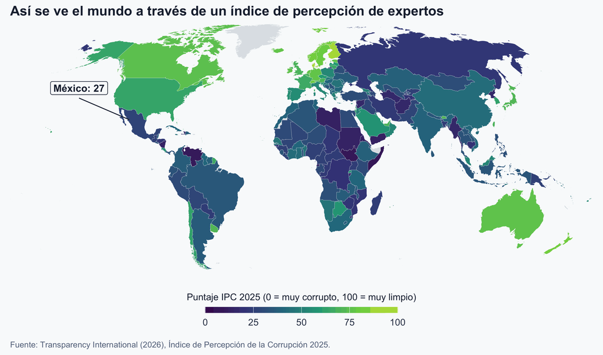

182 países con puntaje, gris = muy pocas fuentes. Un número por país por año.

## De trece fuentes a un solo número

El IPC no levanta encuesta propia; promedia las de trece terceros.

```
%%{init: {"theme":"base","width":1150,"height":520,
  "themeVariables":{"fontSize":"20px","fontFamily":"Helvetica, Arial, sans-serif",
    "primaryColor":"#f4f6f8","primaryTextColor":"#1e293b",
    "primaryBorderColor":"#64748b","lineColor":"#334155","textColor":"#1e293b"},
  "flowchart":{"useMaxWidth":true,"htmlLabels":true,"nodeSpacing":26,"rankSpacing":55,
    "curve":"basis","padding":30}} }%%
flowchart LR
  A["13 fuentes<br/>mínimo 3 por país"] --> B["Reescalar cada<br/>una de 0 a 100"]
  B --> C["Promedio<br/>simple"]
  C --> D["Un puntaje,<br/>más un rango"]
  classDef inp fill:#fdf2ef,stroke:#b44527,stroke-width:2px,color:#1e293b;
  classDef step fill:#f4f6f8,stroke:#64748b,stroke-width:2px,color:#1e293b;
  classDef out fill:#eef3f1,stroke:#4a7c6f,stroke-width:2px,color:#1e293b;
  class A inp;
  class B,C step;
  class D out;
```

El rango dice qué tan lejos estaban las fuentes entre sí: más rango, menos acuerdo.

Ese rango tiene un nombre técnico: **intervalo de confianza**. Lo van a volver a ver; por ahora, léanlo como “cuánto discutieron las fuentes”.

Fuente: Transparency International (2026), *CPI Technical Methodology Note*. El reescalamiento es un puntaje z contra un año base, fijado en media 45 y desviación estándar 20. Tres de las trece fuentes corren al revés y se invierten primero.

## Ocho fuentes, un puntaje

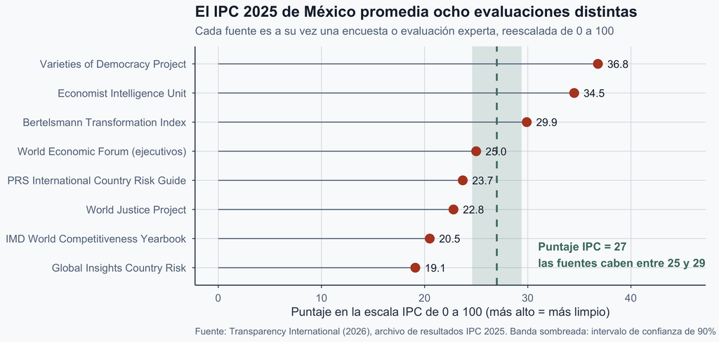

Las fuentes difieren en 18 puntos sobre el mismo país y el mismo año.

## Por qué las fuentes no coinciden

Las ocho fuentes de México van de 19 a 37. Cinco razones, ninguna es un error.

- Califican cosas distintas: soborno, nepotismo, captura del Estado
- Algunas califican la maquinaria: juicios, reglas de transparencia, protección a denunciantes
- Le preguntan a gente distinta: ejecutivos, analistas de riesgo, académicos
- Traen fechas distintas: las de México van de 2024 a 2026
- Cada una tenía su escala antes de reescalarse a 0-100

El compuesto promedia ese desacuerdo en lugar de resolverlo.

Fuentes: Transparency International (2026), *CPI Technical Methodology Note* y *CPI 2025 Full Source Description*.

## Qué significa que un puntaje baje

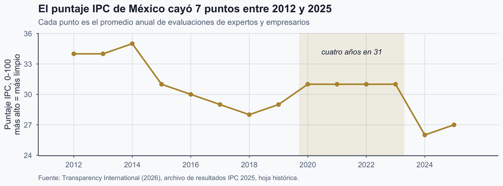

Cuatro años con el mismo puntaje, y luego una caída de cinco puntos en 2024.

Que el puntaje IPC caiga muestra que cambiaron las evaluaciones, todavía no que cambió la conducta.

## Familia 2: experiencia de gente y empresas

- Pregunta qué **le pasó** a la gente, no qué opina
- La ENCIG del INEGI encuesta hogares en el México urbano
- Enterprise Surveys: al **15.8%** de las empresas mexicanas les pidieron algo
- En la encuesta de Olken, 8.9% no quiso contestar sobre corrupción
- El denominador importa: solo cuentan quienes tuvieron **contacto**
- Ciega a la gran corrupción: compras públicas, contratos, captura política

[figure not shown]

INEGI, Ciudad de México. Foto: Tbhotch, Wikimedia Commons, CC BY-SA 4.0. Cifra de empresas: Banco Mundial, Enterprise Surveys.

## Familia 3: auditorías y dinero faltante

Una auditoría física, no una opinión.

- Olken estudió **477** caminos rurales en Java
- Ingenieros midieron lo construido y cotizaron los materiales
- Costo reportado menos costo estimado = **gasto faltante**
- En promedio faltaba el **24%** del gasto reportado
- Uganda, 1991-95: a las escuelas les llegaba apenas el **13%**

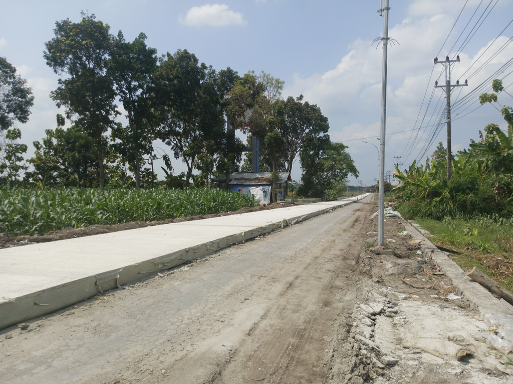

Camino rural en pavimentación, Klaten, Java Central. Foto: Dani Safa Adi Nugraha, [Wikimedia Commons](https://commons.wikimedia.org/wiki/File:Renovasi_Penambahan_Lapisan_Jalan_Lingkar_Utara_Pedan_di_Selatan_Umbul_Kedungan.jpg), CC BY-SA 4.0.

Fuentes: Olken (2007, 2009); Reinikka y Svensson (2004).

## Por dónde se fue el dinero

Robarle al camino: ¿falsear el **precio** o la **cantidad**?

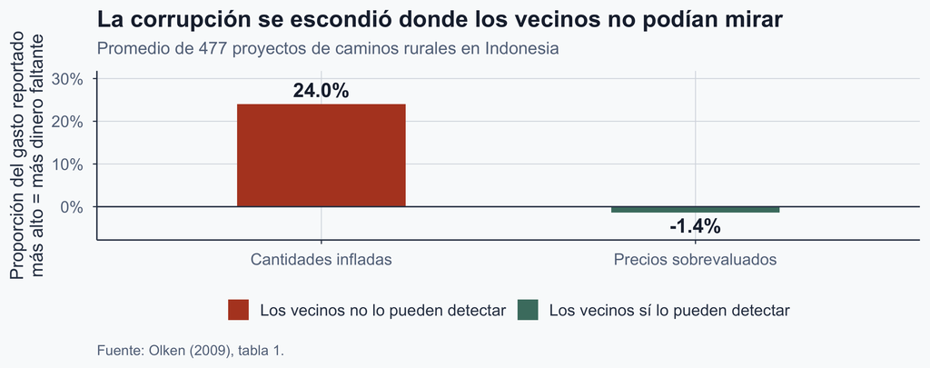

La corrupción se movió a la dimensión que nadie podía revisar.

## Por qué las cantidades son invisibles

[figure not shown]

Entrega de grava, valle del Marsyangdi, Nepal. Foto: Greg Willis, Wikimedia Commons, CC BY-SA 2.0.

- Todo el pueblo sabe cuánto cuesta un metro de grava
- Nadie puede calcular a ojo cuántos metros cúbicos llegaron
- Por eso inflaron **cantidades**, que nadie podía revisar
- La detección moldea el delito, no solo nuestra medición
- La lección de Olken: auditar requiere **especialistas**, no solo ojos

## Familia 4: inferencia a partir de precios

El soborno no queda registrado, pero el precio es público.

- Tras la invasión de Kuwait, la ONU prohibió exportar petróleo iraquí
- **Petróleo por Alimentos** (1997-2003) lo dejó vender, para lo humanitario
- Iba todo a una **cuenta controlada por la ONU**, no a Bagdad
- Irak seguía eligiendo **quién** podía comprarle el petróleo
- Hasta 2001 también proponía el precio, con visto bueno de la ONU
- Y proponía un precio **por debajo** del mercado mundial

¿Por qué un gobierno vendería su propio petróleo demasiado barato?

Fuente: Hsieh y Moretti (2006).

## ¿Por qué venderlo tan barato?

Porque el petróleo era barato, pero el **derecho a comprarlo** no.

```
%%{init: {"theme":"base","width":1150,"height":360,
  "themeVariables":{"fontSize":"19px","fontFamily":"Helvetica, Arial, sans-serif",
    "primaryColor":"#f4f6f8","primaryTextColor":"#1e293b",
    "primaryBorderColor":"#64748b","lineColor":"#334155","textColor":"#1e293b"},
  "flowchart":{"useMaxWidth":true,"htmlLabels":true,"nodeSpacing":28,"rankSpacing":58,
    "curve":"basis","padding":26}} }%%
flowchart LR
  A["El dinero queda<br/>en una cuenta<br/>de la ONU"] --> B["Vender el crudo<br/>debajo del<br/>precio de mercado"]
  B --> C["El descuento es<br/>un regalo que<br/>Irak reparte"]
  C --> D["El comprador paga<br/>efectivo a Bagdad,<br/>fuera de esa cuenta"]
  classDef block fill:#eef3f1,stroke:#4a7c6f,stroke-width:2px,color:#1e293b;
  classDef gift fill:#fdf2ef,stroke:#b44527,stroke-width:2px,color:#1e293b;
  class A,B block;
  class C,D gift;
```

Abarata el bien y luego vende el derecho a comprarlo.

Como poner en 100 pesos un boleto que vale 150, elegir quién lo compra, y quedarte con 30 por fuera.

## Barato solo mientras Irak ponía el precio

El crudo iraquí y el saudita son casi iguales. Normalmente cuestan lo mismo.

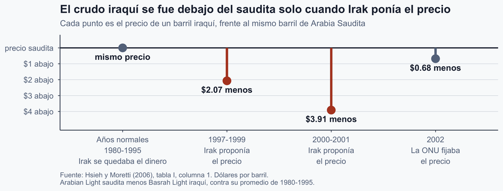

Mismo crudo, mismos compradores, mismo mercado. Lo único que cambió fue la regla del precio.

Los documentos incautados detectaron $230 millones de efectivo de los compradores a Bagdad. Los precios implican **$1,300 millones**.

# III. La brecha entre percepción y experiencia

## Doce años, dos historias distintas

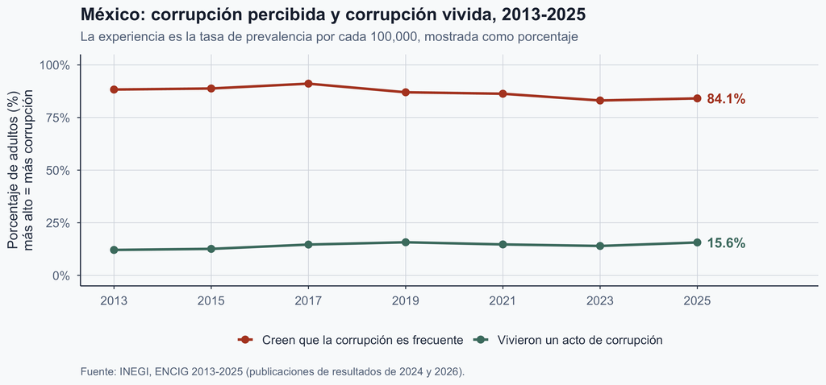

De 2017 a 2023 la percepción cae 8 puntos mientras la experiencia casi no se mueve.

## Por qué las dos se separan

- **Objeto distinto**: la corrupción del Estado contra mi trámite
- **Cobertura**: un escándalo sube la percepción sin subir los sobornos
- **Memoria**: uno recuerda los casos sonados, no su propio año
- **Denominador**: la experiencia solo cuenta a quien tuvo contacto
- **Quién responde**: los expertos evalúan países, la gente reporta hechos
- Los países ricos y democráticos salen mejor que su experiencia

Que se denuncie más puede subir la corrupción percibida mientras la vivida baja.

Fuente del último punto: Donchev y Ujhelyi (2014).

## ¿Los vecinos sí saben?

Olken les preguntó a los vecinos cuánta corrupción hubo en su propio camino.

- Le atinaban en parte: más dinero faltante, más sospecha
- Pero apenas: 10% más faltante mueve la sospecha de 36.0% a 36.3%
- Y quién eres importa: escolaridad y género moldean la respuesta
- Los pueblos con más diversidad étnica reportan **más** corrupción
- Y a esos mismos pueblos les faltaba **menos** dinero

¿Cómo pueden ser ciertas las dos últimas a la vez?

Fuente: Olken (2009), 3,691 encuestados en 477 pueblos. La escolaridad y el género siguen moldeando las respuestas incluso comparando un pueblo solo consigo mismo.

## Cómo la sospecha puede bajar la corrupción

Una sola cadena vuelve ciertos a la vez los dos últimos hallazgos.

```
%%{init: {"theme":"base","width":1150,"height":360,
  "themeVariables":{"fontSize":"19px","fontFamily":"Helvetica, Arial, sans-serif",
    "primaryColor":"#f4f6f8","primaryTextColor":"#1e293b",
    "primaryBorderColor":"#64748b","lineColor":"#334155","textColor":"#1e293b"},
  "flowchart":{"useMaxWidth":true,"htmlLabels":true,"nodeSpacing":28,"rankSpacing":58,
    "curve":"basis","padding":26}} }%%
flowchart LR
  A["Pueblo diverso,<br/>menos confianza<br/>entre vecinos"] --> B["Más sospecha<br/>de las<br/>autoridades"]
  B --> C["Más vecinos<br/>van y<br/>vigilan"]
  C --> D["Falta menos<br/>dinero de<br/>verdad"]
  classDef belief fill:#fdf2ef,stroke:#b44527,stroke-width:2px,color:#1e293b;
  classDef doing fill:#eef3f1,stroke:#4a7c6f,stroke-width:2px,color:#1e293b;
  class A,B belief;
  class C,D doing;
```

La sospecha puede reducir lo que mide.

Elaboración propia, a partir de Olken (2009).

## Ejercicio: interrogar un titular

**En parejas.** Un periódico publica: *“La corrupción en México subió 20% el año pasado.”*

Anoten **todas** las preguntas que necesitarían responder antes de creerlo.

Luego decidan: ¿cuál de sus preguntas le costaría más trabajo contestar al periodista?

# IV. Emparejar afirmaciones con medidas

## Qué puede sostener cada familia

Tabla 3: Cuatro familias de medidas de corrupción, y sus límites.

| Familia | Qué o a quién observa | Qué afirmación sostiene | Cómo engaña |
| --- | --- | --- | --- |
| Percepción de expertos | Expertos, ejecutivos de empresas | Comparación amplia entre países | La reputación y las noticias mueven el puntaje |
| Experiencia de gente y empresas | Hogares, empresas | Prevalencia del soborno cotidiano, y su cambio | Se subreporta; ciega a la gran corrupción |
| Auditorías y dinero faltante | Cantidades físicas, registros | Fuga de recursos en un programa | Cara; un sector a la vez |
| Inferencia a partir de precios | Precios en un mercado | Tamaño de una transferencia oculta | Una brecha de precios puede tener causas inocentes |

Síntesis propia, con base en Sequeira (2012) y Olken (2009). No es exhaustiva: los expedientes judiciales, las banderas rojas en compras públicas y la observación directa son otras familias.

## Entonces, ¿mejor o peor?

De regreso a la pregunta que la redacción no pudo resolver.

- Cuatro familias: percepción, experiencia, auditorías, precios
- El puntaje IPC cayó de 29 a 27 desde 2017
- La frecuencia percibida bajó de 91.1% en 2017 a 84.1%
- La corrupción vivida subió de 14.6% en 2017 a 15.6%
- Rastros distintos, tendencias distintas, preguntas distintas
- “Depende de qué contaste” es la respuesta disciplinada

Toda cifra mide un rastro, así que pregunten qué lo dejó.

## Conclusión

Cinco cosas para llevarse de esta sesión.

- Casi toda medida cuenta un **rastro**, no el acto mismo
- México 2025: 84% cree que es frecuente, 16% la vivió
- Ocho fuentes expertas calificaron a México entre 19 y 37
- En Java el robo se escondió en las cantidades, donde nadie revisaba
- Más sospecha y menos dinero robado pueden ir juntos

## Referencias

Donchev, D., & Ujhelyi, G. (2014). What do corruption indices measure? *Economics & Politics, 26*(2), 309–331. https://doi.org/10.1111/ecpo.12037

Hsieh, C.-T., & Moretti, E. (2006). Did Iraq cheat the United Nations? Underpricing, bribes, and the Oil for Food Program. *The Quarterly Journal of Economics, 121*(4), 1211–1248.

Instituto Nacional de Estadística y Geografía. (2024). *Encuesta Nacional de Calidad e Impacto Gubernamental (ENCIG) 2023: Principales resultados*. INEGI.

Instituto Nacional de Estadística y Geografía. (2026). *Encuesta Nacional de Calidad e Impacto Gubernamental (ENCIG) 2025* (Comunicado de prensa 28/26; Reporte de resultados 16/26). INEGI.

Olken, B. A. (2007). Monitoring corruption: Evidence from a field experiment in Indonesia. *Journal of Political Economy, 115*(2), 200–249.

Olken, B. A. (2009). Corruption perceptions vs. corruption reality. *Journal of Public Economics, 93*(7–8), 950–964.

## Referencias (continuación)

Reinikka, R., & Svensson, J. (2004). Local capture: Evidence from a central government transfer program in Uganda. *The Quarterly Journal of Economics, 119*(2), 679–705.

Sequeira, S. (2012). Advances in measuring corruption in the field. In D. Serra & L. Wantchekon (Eds.), *New advances in experimental research on corruption* (Research in Experimental Economics, Vol. 15, pp. 145–176). Emerald. https://doi.org/10.1108/S0193-2306(2012)0000015008

Transparency International. (2026). *Corruption Perceptions Index 2025*. Transparency International.

World Bank. (2026). *Enterprise Surveys: Bribery incidence, percent of firms experiencing at least one bribe payment request* (IC.FRM.BRIB.ZS) [Data set]. World Bank.